# INN Hotels Project

## Context

A significant number of hotel bookings are called-off due to cancellations or no-shows. The typical reasons for cancellations include change of plans, scheduling conflicts, etc. This is often made easier by the option to do so free of charge or preferably at a low cost which is beneficial to hotel guests but it is a less desirable and possibly revenue-diminishing factor for hotels to deal with. Such losses are particularly high on last-minute cancellations.

The new technologies involving online booking channels have dramatically changed customers’ booking possibilities and behavior. This adds a further dimension to the challenge of how hotels handle cancellations, which are no longer limited to traditional booking and guest characteristics.

The cancellation of bookings impact a hotel on various fronts:

- Loss of resources (revenue) when the hotel cannot resell the room.
- Additional costs of distribution channels by increasing commissions or paying for publicity to help sell these rooms.
- Lowering prices last minute, so the hotel can resell a room, resulting in reducing the profit margin.
- Human resources to make arrangements for the guests.

## Objective

The increasing number of cancellations calls for a Machine Learning based solution that can help in predicting which booking is likely to be canceled. INN Hotels Group has a chain of hotels in Portugal, they are facing problems with the high number of booking cancellations and have reached out to your firm for data-driven solutions. You as a data scientist have to analyze the data provided to find which factors have a high influence on booking cancellations, build a predictive model that can predict which booking is going to be canceled in advance, and help in formulating profitable policies for cancellations and refunds.

## Data Description

The data contains the different attributes of customers' booking details. The detailed data dictionary is given below.

**Data Dictionary**

- Booking_ID: unique identifier of each booking
- no_of_adults: Number of adults
- no_of_children: Number of Children
- no_of_weekend_nights: Number of weekend nights (Saturday or Sunday) the guest stayed or booked to stay at the hotel
- no_of_week_nights: Number of week nights (Monday to Friday) the guest stayed or booked to stay at the hotel
- type_of_meal_plan: Type of meal plan booked by the customer:
  - Not Selected – No meal plan selected
  - Meal Plan 1 – Breakfast
  - Meal Plan 2 – Half board (breakfast and one other meal)
  - Meal Plan 3 – Full board (breakfast, lunch, and dinner)
- required_car_parking_space: Does the customer require a car parking space? (0 - No, 1- Yes)
- room_type_reserved: Type of room reserved by the customer. The values are ciphered (encoded) by INN Hotels.
- lead_time: Number of days between the date of booking and the arrival date
- arrival_year: Year of arrival date
- arrival_month: Month of arrival date
- arrival_date: Date of the month
- market_segment_type: Market segment designation.
- repeated_guest: Is the customer a repeated guest? (0 - No, 1- Yes)
- no_of_previous_cancellations: Number of previous bookings that were canceled by the customer prior to the current booking
- no_of_previous_bookings_not_canceled: Number of previous bookings not canceled by the customer prior to the current booking
- avg_price_per_room: Average price per day of the reservation; prices of the rooms are dynamic. (in euros)
- no_of_special_requests: Total number of special requests made by the customer (e.g. high floor, view from the room, etc)
- booking_status: Flag indicating if the booking was canceled or not.

## Importing necessary libraries and data

```python
import numpy as np
import pandas as pd

import matplotlib.pyplot as plt
import seaborn as sns

sns.set()

from sklearn.model_selection import train_test_split

from sklearn.linear_model import LinearRegression

from sklearn.metrics import mean_absolute_error, mean_squared_error, r2_score

import statsmodels.api as sm

from statsmodels.stats.outliers_influence import variance_inflation_factor
```

```python
from google.colab import drive
drive.mount('/content/drive')

df = pd.read_csv('/content/drive/My Drive/INNHotelsGroup.csv')
```

## Data Overview

- Observations
- Sanity checks

```python
df.head()
```

|  | Booking_ID | no_of_adults | no_of_children | no_of_weekend_nights | no_of_week_nights | type_of_meal_plan | required_car_parking_space | room_type_reserved | lead_time | arrival_year | arrival_month | arrival_date | market_segment_type | repeated_guest | no_of_previous_cancellations | no_of_previous_bookings_not_canceled | avg_price_per_room | no_of_special_requests | booking_status |
| --- | --- | --- | --- | --- | --- | --- | --- | --- | --- | --- | --- | --- | --- | --- | --- | --- | --- | --- | --- |
| 0 | INN00001 | 2 | 0 | 1 | 2 | Meal Plan 1 | 0 | Room_Type 1 | 224 | 2017 | 10 | 2 | Offline | 0 | 0 | 0 | 65.00 | 0 | Not_Canceled |
| 1 | INN00002 | 2 | 0 | 2 | 3 | Not Selected | 0 | Room_Type 1 | 5 | 2018 | 11 | 6 | Online | 0 | 0 | 0 | 106.68 | 1 | Not_Canceled |
| 2 | INN00003 | 1 | 0 | 2 | 1 | Meal Plan 1 | 0 | Room_Type 1 | 1 | 2018 | 2 | 28 | Online | 0 | 0 | 0 | 60.00 | 0 | Canceled |
| 3 | INN00004 | 2 | 0 | 0 | 2 | Meal Plan 1 | 0 | Room_Type 1 | 211 | 2018 | 5 | 20 | Online | 0 | 0 | 0 | 100.00 | 0 | Canceled |
| 4 | INN00005 | 2 | 0 | 1 | 1 | Not Selected | 0 | Room_Type 1 | 48 | 2018 | 4 | 11 | Online | 0 | 0 | 0 | 94.50 | 0 | Canceled |

```python
df.tail()
```

|  | Booking_ID | no_of_adults | no_of_children | no_of_weekend_nights | no_of_week_nights | type_of_meal_plan | required_car_parking_space | room_type_reserved | lead_time | arrival_year | arrival_month | arrival_date | market_segment_type | repeated_guest | no_of_previous_cancellations | no_of_previous_bookings_not_canceled | avg_price_per_room | no_of_special_requests | booking_status |
| --- | --- | --- | --- | --- | --- | --- | --- | --- | --- | --- | --- | --- | --- | --- | --- | --- | --- | --- | --- |
| 36270 | INN36271 | 3 | 0 | 2 | 6 | Meal Plan 1 | 0 | Room_Type 4 | 85 | 2018 | 8 | 3 | Online | 0 | 0 | 0 | 167.80 | 1 | Not_Canceled |
| 36271 | INN36272 | 2 | 0 | 1 | 3 | Meal Plan 1 | 0 | Room_Type 1 | 228 | 2018 | 10 | 17 | Online | 0 | 0 | 0 | 90.95 | 2 | Canceled |
| 36272 | INN36273 | 2 | 0 | 2 | 6 | Meal Plan 1 | 0 | Room_Type 1 | 148 | 2018 | 7 | 1 | Online | 0 | 0 | 0 | 98.39 | 2 | Not_Canceled |
| 36273 | INN36274 | 2 | 0 | 0 | 3 | Not Selected | 0 | Room_Type 1 | 63 | 2018 | 4 | 21 | Online | 0 | 0 | 0 | 94.50 | 0 | Canceled |
| 36274 | INN36275 | 2 | 0 | 1 | 2 | Meal Plan 1 | 0 | Room_Type 1 | 207 | 2018 | 12 | 30 | Offline | 0 | 0 | 0 | 161.67 | 0 | Not_Canceled |

```python
df.shape
```

```
(36275, 19)
```

```python
df.info
```

[output not shown]

[output cut: 64 more lines]

```python
statistical_summary = df.describe()
print(statistical_summary)
```

```
       no_of_adults  no_of_children  no_of_weekend_nights  no_of_week_nights  \
count  36275.000000    36275.000000          36275.000000       36275.000000
mean       1.844962        0.105279              0.810724           2.204300
std        0.518715        0.402648              0.870644           1.410905
min        0.000000        0.000000              0.000000           0.000000
25%        2.000000        0.000000              0.000000           1.000000
50%        2.000000        0.000000              1.000000           2.000000
75%        2.000000        0.000000              2.000000           3.000000
max        4.000000       10.000000              7.000000          17.000000

       required_car_parking_space     lead_time  arrival_year  arrival_month  \
count                36275.000000  36275.000000  36275.000000   36275.000000
mean                     0.030986     85.232557   2017.820427       7.423653
std                      0.173281     85.930817      0.383836       3.069894
min                      0.000000      0.000000   2017.000000       1.000000
25%                      0.000000     17.000000   2018.000000       5.000000
50%                      0.000000     57.000000   2018.000000       8.000000
75%                      0.000000    126.000000   2018.000000      10.000000
max                      1.000000    443.000000   2018.000000      12.000000

       arrival_date  repeated_guest  no_of_previous_cancellations  \
count  36275.000000    36275.000000                  36275.000000
mean      15.596995        0.025637                      0.023349
std        8.740447        0.158053                      0.368331
min        1.000000        0.000000                      0.000000
25%        8.000000        0.000000                      0.000000
50%       16.000000        0.000000                      0.000000
75%       23.000000        0.000000                      0.000000
max       31.000000        1.000000                     13.000000

       no_of_previous_bookings_not_canceled  avg_price_per_room  \
count                          36275.000000        36275.000000
mean                               0.153411          103.423539
std                                1.754171           35.089424
min                                0.000000            0.000000
25%                                0.000000           80.300000
50%                                0.000000           99.450000
75%                                0.000000          120.000000
max                               58.000000          540.000000

       no_of_special_requests
count            36275.000000
mean                 0.619655
std                  0.786236
min                  0.000000
25%                  0.000000
50%                  0.000000
75%                  1.000000
max                  5.000000
```

```python
duplicates = df[df.duplicated()]
print("Duplicate rows in the DataFrame:")
print(duplicates)
```

[output not shown]

```python
missing_values = df.isnull().sum()
print("Missing values in each column:")
print(missing_values)
```

```
Missing values in each column:
Booking_ID                              0
no_of_adults                            0
no_of_children                          0
no_of_weekend_nights                    0
no_of_week_nights                       0
type_of_meal_plan                       0
required_car_parking_space              0
room_type_reserved                      0
lead_time                               0
arrival_year                            0
arrival_month                           0
arrival_date                            0
market_segment_type                     0
repeated_guest                          0
no_of_previous_cancellations            0
no_of_previous_bookings_not_canceled    0
avg_price_per_room                      0
no_of_special_requests                  0
booking_status                          0
dtype: int64
```

## Exploratory Data Analysis (EDA)

- EDA is an important part of any project involving data.
- It is important to investigate and understand the data better before building a model with it.
- A few questions have been mentioned below which will help you approach the analysis in the right manner and generate insights from the data.
- A thorough analysis of the data, in addition to the questions mentioned below, should be done.

**Leading Questions**:

1. What are the busiest months in the hotel?
2. Which market segment do most of the guests come from?
3. Hotel rates are dynamic and change according to demand and customer demographics. What are the differences in room prices in different market segments?
4. What percentage of bookings are canceled?
5. Repeating guests are the guests who stay in the hotel often and are important to brand equity. What percentage of repeating guests cancel?
6. Many guests have special requirements when booking a hotel room. Do these requirements affect booking cancellation?

### Univariate Analysis

```python
def histogram_boxplot(data, feature, figsize=(15, 10), kde=False, bins=None):
    """
    Boxplot and histogram combined

    data: dataframe
    feature: dataframe column
    figsize: size of figure (default (15,10))
    kde: whether to show the density curve (default False)
    bins: number of bins for histogram (default None)
    """
    f2, (ax_box2, ax_hist2) = plt.subplots(
        nrows=2,
        sharex=True,
        gridspec_kw={"height_ratios": (0.25, 0.75)},
        figsize=figsize,
    )
    sns.boxplot(
        data=data, x=feature, ax=ax_box2, showmeans=True, color="violet"
    )
    sns.histplot(
        data=data, x=feature, kde=kde, ax=ax_hist2, bins=bins
    ) if bins else sns.histplot(
        data=data, x=feature, kde=kde, ax=ax_hist2
    )
    ax_hist2.axvline(
        data[feature].mean(), color="green", linestyle="--"
    )
    ax_hist2.axvline(
        data[feature].median(), color="black", linestyle="-"
    )
```

```python
def labeled_barplot(data, feature, perc=False, n=None):
    """
    Barplot with percentage at the top

    data: dataframe
    feature: dataframe column
    perc: whether to display percentages instead of count (default is False)
    n: displays the top n category levels (default is None, i.e., display all levels)
    """

    total = len(data[feature])
    count = data[feature].nunique()
    if n is None:
        plt.figure(figsize=(count + 2, 6))
    else:
        plt.figure(figsize=(n + 2, 6))

    plt.xticks(rotation=90, fontsize=15)
    ax = sns.countplot(
        data=data,
        x=feature,
        palette="Paired",
        order=data[feature].value_counts().index[:n],
    )

    for p in ax.patches:
        if perc == True:
            label = "{:.1f}%".format(
                100 * p.get_height() / total
            )
        else:
            label = p.get_height()

        x = p.get_x() + p.get_width() / 2
        y = p.get_height()

        ax.annotate(
            label,
            (x, y),
            ha="center",
            va="center",
            size=12,
            xytext=(0, 5),
            textcoords="offset points",
        )

    plt.show()
```

### Observations on lead time

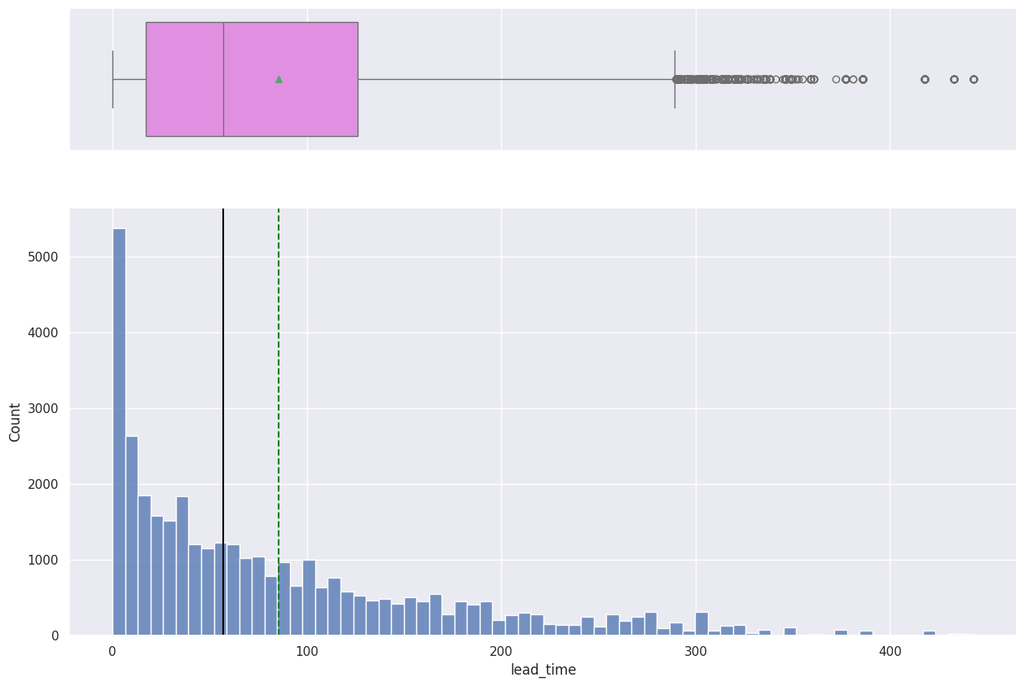

```python
histogram_boxplot(df, "lead_time")
```

### Observations on average price per room

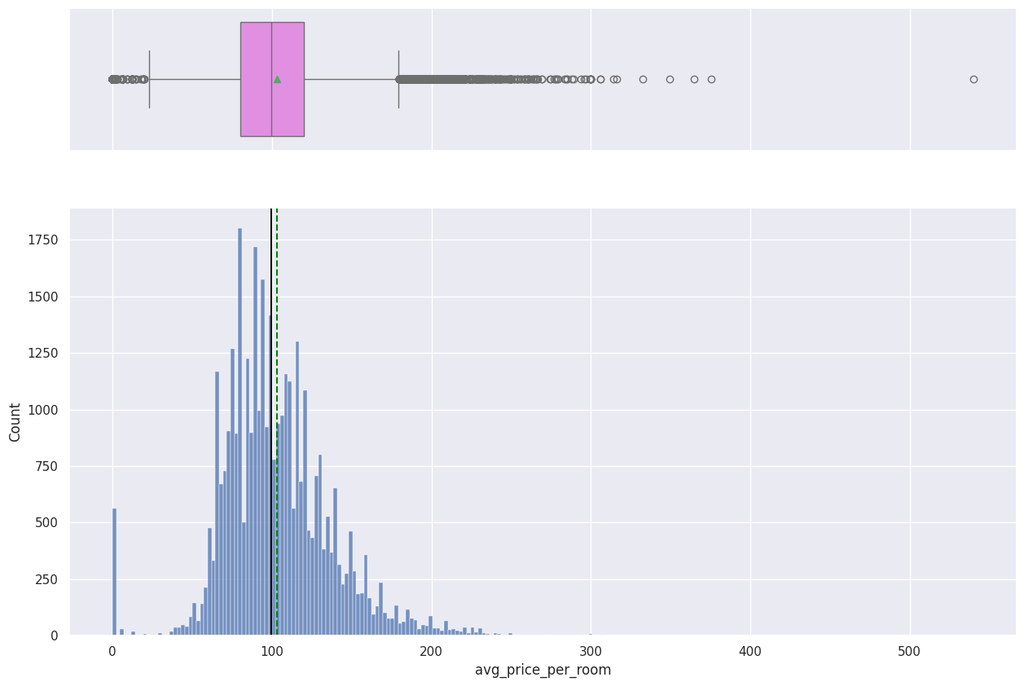

```python
histogram_boxplot(df,'avg_price_per_room')
```

```python
df[df["avg_price_per_room"] == 0]
```

|  | Booking_ID | no_of_adults | no_of_children | no_of_weekend_nights | no_of_week_nights | type_of_meal_plan | required_car_parking_space | room_type_reserved | lead_time | arrival_year | arrival_month | arrival_date | market_segment_type | repeated_guest | no_of_previous_cancellations | no_of_previous_bookings_not_canceled | avg_price_per_room | no_of_special_requests | booking_status |
| --- | --- | --- | --- | --- | --- | --- | --- | --- | --- | --- | --- | --- | --- | --- | --- | --- | --- | --- | --- |
| 63 | INN00064 | 1 | 0 | 0 | 1 | Meal Plan 1 | 0 | Room_Type 1 | 2 | 2017 | 9 | 10 | Complementary | 0 | 0 | 0 | 0.0 | 1 | Not_Canceled |
| 145 | INN00146 | 1 | 0 | 0 | 2 | Meal Plan 1 | 0 | Room_Type 1 | 13 | 2018 | 6 | 1 | Complementary | 1 | 3 | 5 | 0.0 | 1 | Not_Canceled |
| 209 | INN00210 | 1 | 0 | 0 | 0 | Meal Plan 1 | 0 | Room_Type 1 | 4 | 2018 | 2 | 27 | Complementary | 0 | 0 | 0 | 0.0 | 1 | Not_Canceled |
| 266 | INN00267 | 1 | 0 | 0 | 2 | Meal Plan 1 | 0 | Room_Type 1 | 1 | 2017 | 8 | 12 | Complementary | 1 | 0 | 1 | 0.0 | 1 | Not_Canceled |
| 267 | INN00268 | 1 | 0 | 2 | 1 | Meal Plan 1 | 0 | Room_Type 1 | 4 | 2017 | 8 | 23 | Complementary | 0 | 0 | 0 | 0.0 | 1 | Not_Canceled |
| ... | ... | ... | ... | ... | ... | ... | ... | ... | ... | ... | ... | ... | ... | ... | ... | ... | ... | ... | ... |
| 35983 | INN35984 | 1 | 0 | 0 | 1 | Meal Plan 1 | 0 | Room_Type 7 | 0 | 2018 | 6 | 7 | Complementary | 1 | 4 | 17 | 0.0 | 1 | Not_Canceled |
| 36080 | INN36081 | 1 | 0 | 1 | 1 | Meal Plan 1 | 0 | Room_Type 7 | 0 | 2018 | 3 | 21 | Complementary | 1 | 3 | 15 | 0.0 | 1 | Not_Canceled |
| 36114 | INN36115 | 1 | 0 | 0 | 1 | Meal Plan 1 | 0 | Room_Type 1 | 1 | 2018 | 3 | 2 | Online | 0 | 0 | 0 | 0.0 | 0 | Not_Canceled |
| 36217 | INN36218 | 2 | 0 | 2 | 1 | Meal Plan 1 | 0 | Room_Type 2 | 3 | 2017 | 8 | 9 | Online | 0 | 0 | 0 | 0.0 | 2 | Not_Canceled |
| 36250 | INN36251 | 1 | 0 | 0 | 2 | Meal Plan 2 | 0 | Room_Type 1 | 6 | 2017 | 12 | 10 | Online | 0 | 0 | 0 | 0.0 | 0 | Not_Canceled |

545 rows × 19 columns

```python
df.loc[df["avg_price_per_room"] == 0, "market_segment_type"].value_counts()
```

```
Complementary    354
Online           191
Name: market_segment_type, dtype: int64
```

```python
Q1 = df["avg_price_per_room"].quantile(0.25)
```

```python
Q3 = df["avg_price_per_room"].quantile(0.75)
```

```python
IQR = Q3 - Q1
```

```python
Upper_Whisker = Q3 + 1.5 * IQR
Upper_Whisker
```

```
179.55
```

```python
df.loc[df["avg_price_per_room"] >= 500, "avg_price_per_room"] = Upper_Whisker
```

### Observations on number of previous booking cancellations

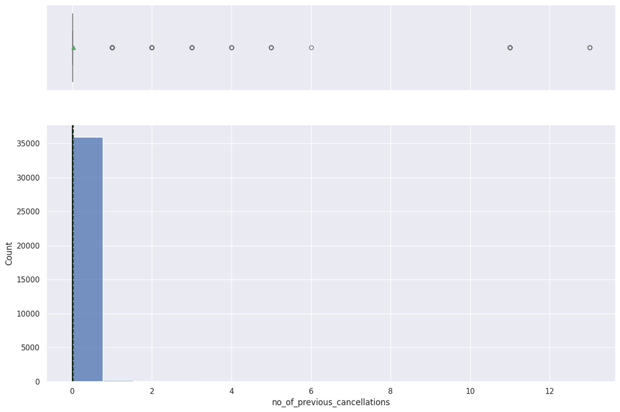

```python
histogram_boxplot(df,'no_of_previous_cancellations')
```

### Observations on number of previous booking not canceled

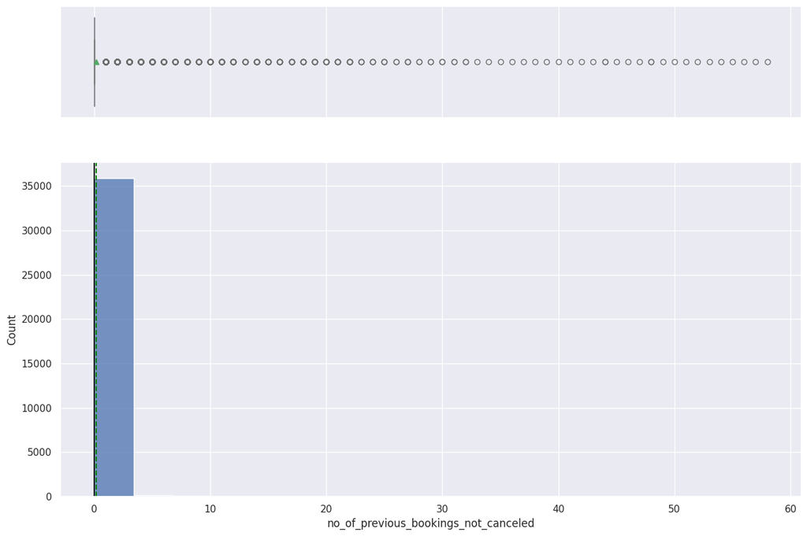

```python
histogram_boxplot(df,'no_of_previous_bookings_not_canceled')
```

```python
def labeled_barplot(data, feature, perc=False, n=None):
    """
    Barplot with percentage at the top

    data: dataframe
    feature: dataframe column
    perc: whether to display percentages instead of count (default is False)
    n: displays the top n category levels (default is None, i.e., display all levels)
    """

    total = len(data[feature])
    count = data[feature].nunique()
    if n is None:
        plt.figure(figsize=(count + 2, 6))
    else:
        plt.figure(figsize=(n + 2, 6))

    plt.xticks(rotation=90, fontsize=15)
    ax = sns.countplot(
        data=data,
        x=feature,
        palette="Paired",
        order=data[feature].value_counts().index[:n],
    )

    for p in ax.patches:
        if perc == True:
            label = "{:.1f}%".format(
                100 * p.get_height() / total
            )
        else:
            label = p.get_height()

        x = p.get_x() + p.get_width() / 2
        y = p.get_height()
        ax.annotate(
            label,
            (x, y),
            ha="center",
            va="center",
            size=12,
            xytext=(0, 5),
            textcoords="offset points",
        )

    plt.show()
```

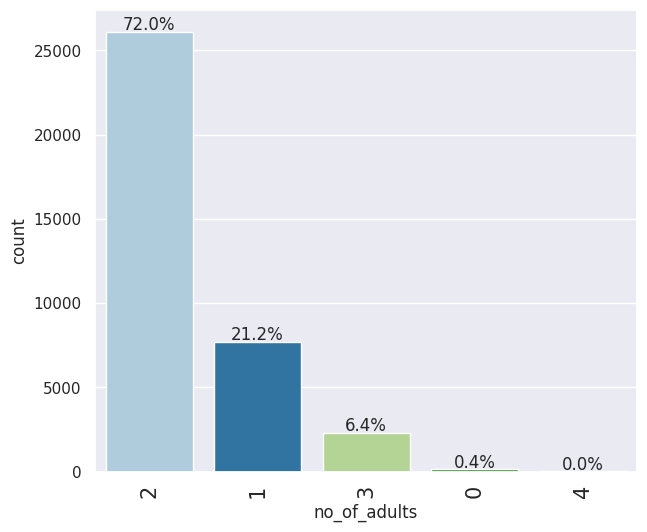

```python
labeled_barplot(df, "no_of_adults", perc=True)
```

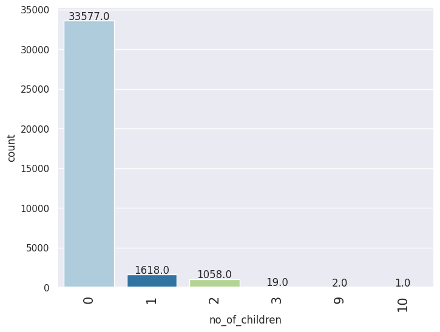

```python
labeled_barplot(df,'no_of_children')
```

```python
df["no_of_children"] = df["no_of_children"].replace([9, 10], 3)
```

### Observations on number of week nights

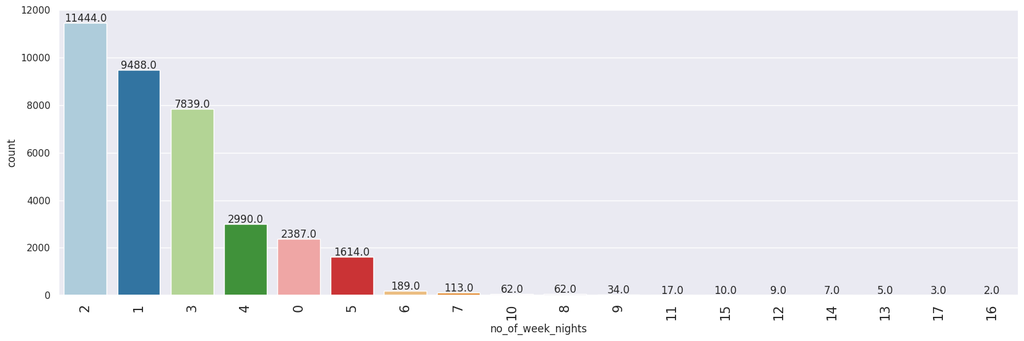

```python
labeled_barplot(df,'no_of_week_nights')
```

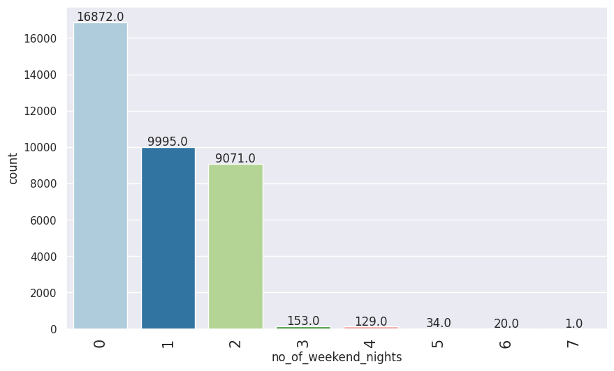

```python
labeled_barplot(df,'no_of_weekend_nights')
```

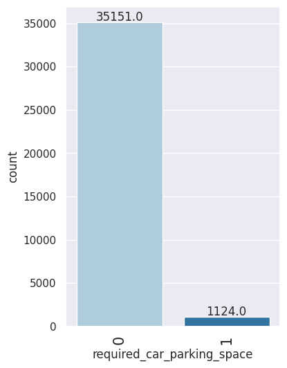

```python
labeled_barplot(df,'required_car_parking_space')
```

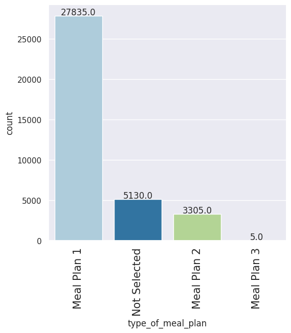

```python
labeled_barplot(df,'type_of_meal_plan')
```

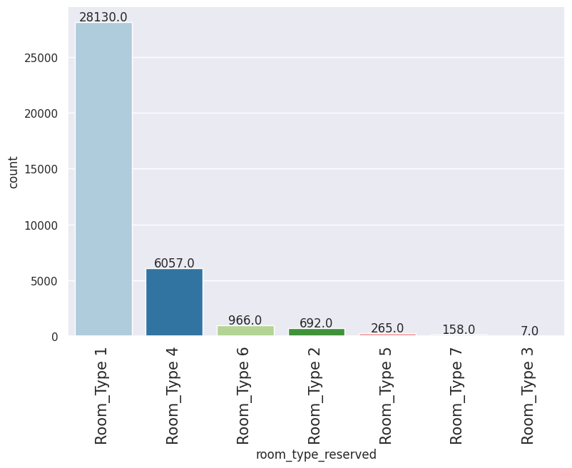

```python
labeled_barplot(df,'room_type_reserved')
```

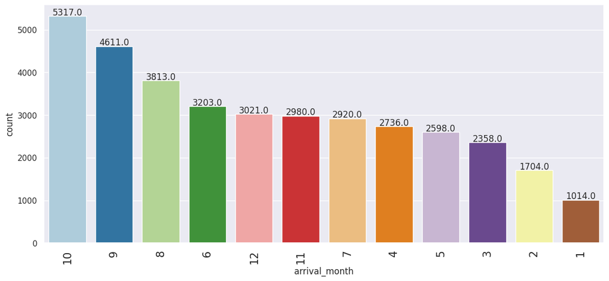

```python
labeled_barplot(df,'arrival_month')
```

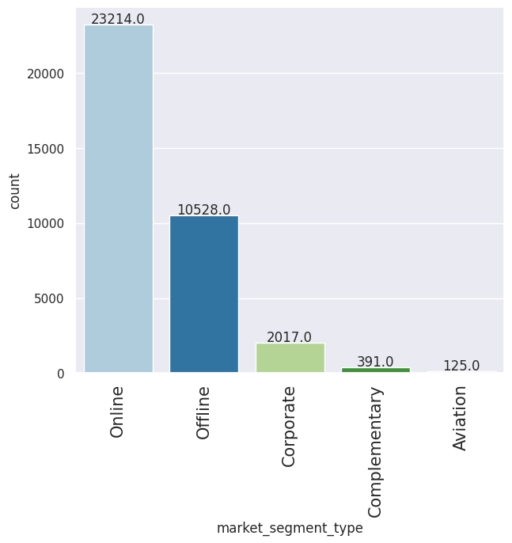

```python
labeled_barplot(df,'market_segment_type')
```

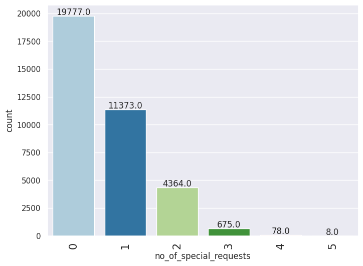

```python
labeled_barplot(df,'no_of_special_requests')
```

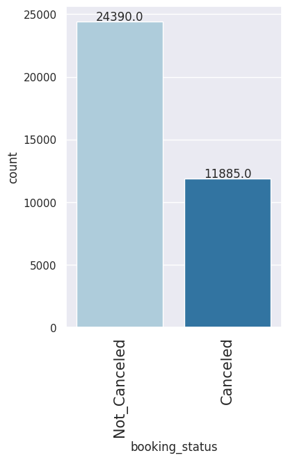

```python
labeled_barplot(df,'booking_status')
```

```python
df["booking_status"] = df["booking_status"].apply(
    lambda x: 1 if x == "Canceled" else 0
)
```

# Bivariate Analysis

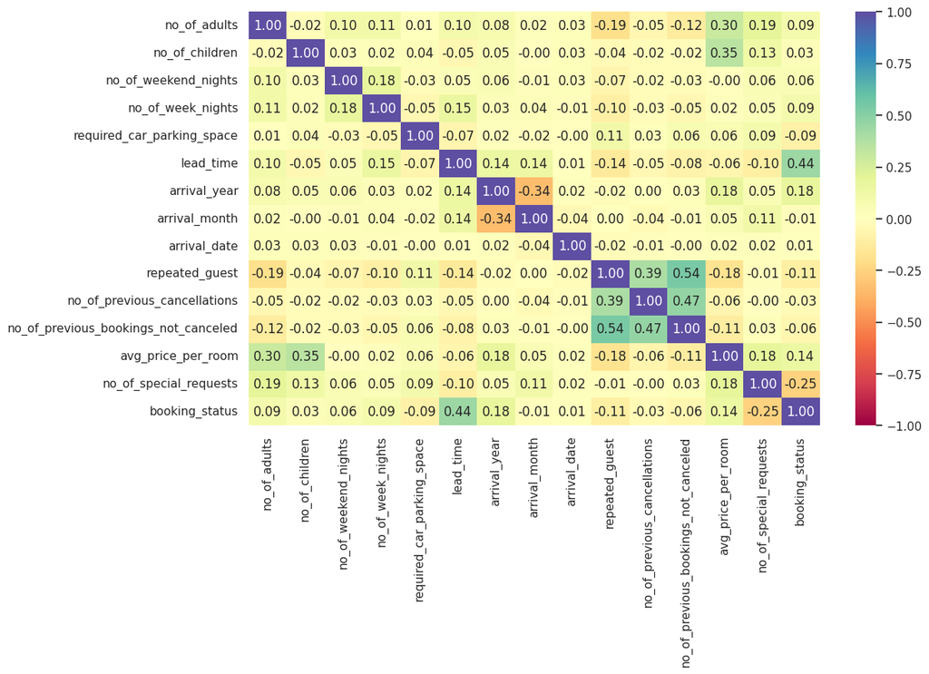

```python
cols_list = df.select_dtypes(include=np.number).columns.tolist()

plt.figure(figsize=(12, 7))
sns.heatmap(
    df[cols_list].corr(), annot=True, vmin=-1, vmax=1, fmt=".2f", cmap="Spectral"
)
plt.show()
```

```python
def distribution_plot_wrt_target(data, predictor, target):

    fig, axs = plt.subplots(2, 2, figsize=(12, 10))

    target_uniq = data[target].unique()

    axs[0, 0].set_title("Distribution of target for target=" + str(target_uniq[0]))
    sns.histplot(
        data=data[data[target] == target_uniq[0]],
        x=predictor,
        kde=True,
        ax=axs[0, 0],
        color="teal",
        stat="density",
    )

    axs[0, 1].set_title("Distribution of target for target=" + str(target_uniq[1]))
    sns.histplot(
        data=data[data[target] == target_uniq[1]],
        x=predictor,
        kde=True,
        ax=axs[0, 1],
        color="orange",
        stat="density",
    )

    axs[1, 0].set_title("Boxplot w.r.t target")
    sns.boxplot(data=data, x=target, y=predictor, ax=axs[1, 0], palette="gist_rainbow")

    axs[1, 1].set_title("Boxplot (without outliers) w.r.t target")
    sns.boxplot(
        data=data,
        x=target,
        y=predictor,
        ax=axs[1, 1],
        showfliers=False,
        palette="gist_rainbow",
    )

    plt.tight_layout()
    plt.show()
```

```python
def stacked_barplot(data, predictor, target):
    """
    Print the category counts and plot a stacked bar chart

    data: dataframe
    predictor: independent variable
    target: target variable
    """
    count = data[predictor].nunique()
    sorter = data[target].value_counts().index[-1]
    tab1 = pd.crosstab(data[predictor], data[target], margins=True).sort_values(
        by=sorter, ascending=False
    )
    print(tab1)
    print("-" * 120)
    tab = pd.crosstab(data[predictor], data[target], normalize="index").sort_values(
        by=sorter, ascending=False
    )
    tab.plot(kind="bar", stacked=True, figsize=(count + 5, 5))
    plt.legend(
        loc="lower left", frameon=False,
    )
    plt.legend(loc="upper left", bbox_to_anchor=(1, 1))
    plt.show()
```

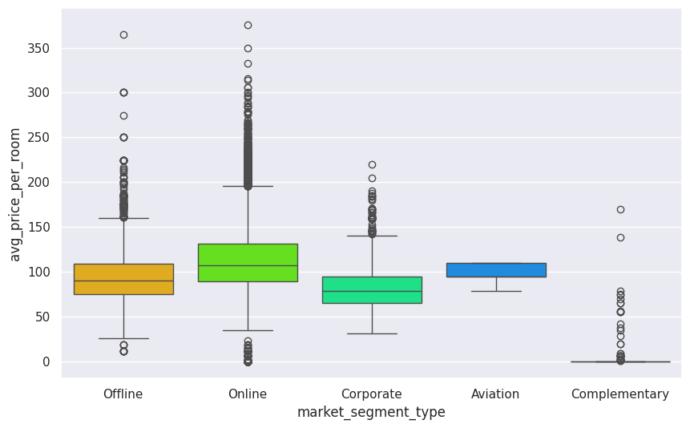

```python
plt.figure(figsize=(10, 6))
sns.boxplot(
    data=df, x="market_segment_type", y="avg_price_per_room", palette="gist_rainbow"
)
plt.show()
```

```
booking_status           0      1    All
market_segment_type
All                  24390  11885  36275
Online               14739   8475  23214
Offline               7375   3153  10528
Corporate             1797    220   2017
Aviation                88     37    125
Complementary          391      0    391
------------------------------------------------------------------------------------------------------------------------
```

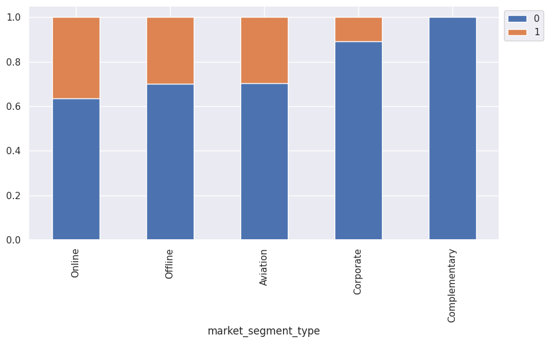

```python
stacked_barplot(df, "market_segment_type", "booking_status")
```

```
booking_status              0      1    All
no_of_special_requests
All                     24390  11885  36275
0                       11232   8545  19777
1                        8670   2703  11373
2                        3727    637   4364
3                         675      0    675
4                          78      0     78
5                           8      0      8
------------------------------------------------------------------------------------------------------------------------
```

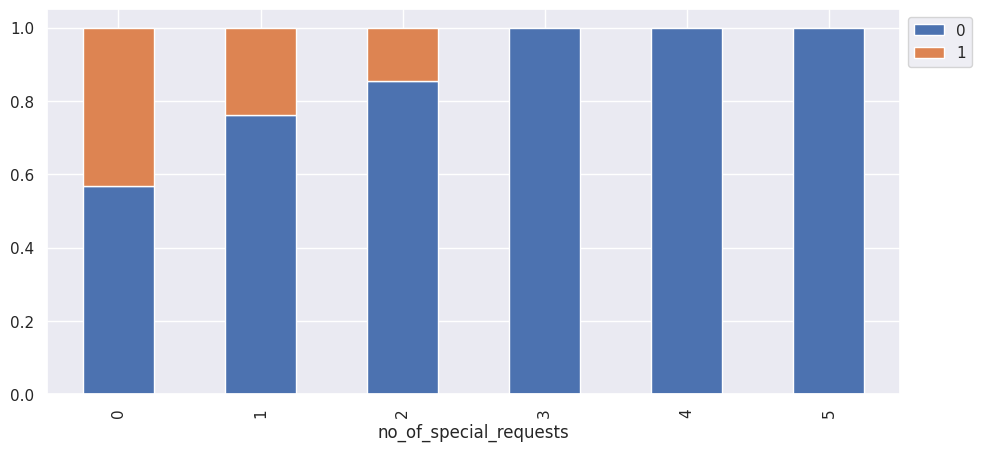

```python
stacked_barplot(df, "no_of_special_requests", "booking_status")
```

[figure not shown]

```python
plt.figure(figsize=(10, 5))
sns.boxplot('df, "no_of_special_requests", "avg_price_per_room"')
plt.show()
```

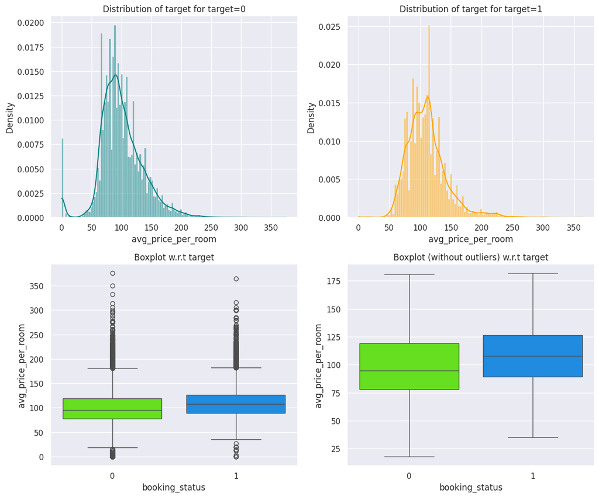

```python
distribution_plot_wrt_target(df, "avg_price_per_room", "booking_status")
```

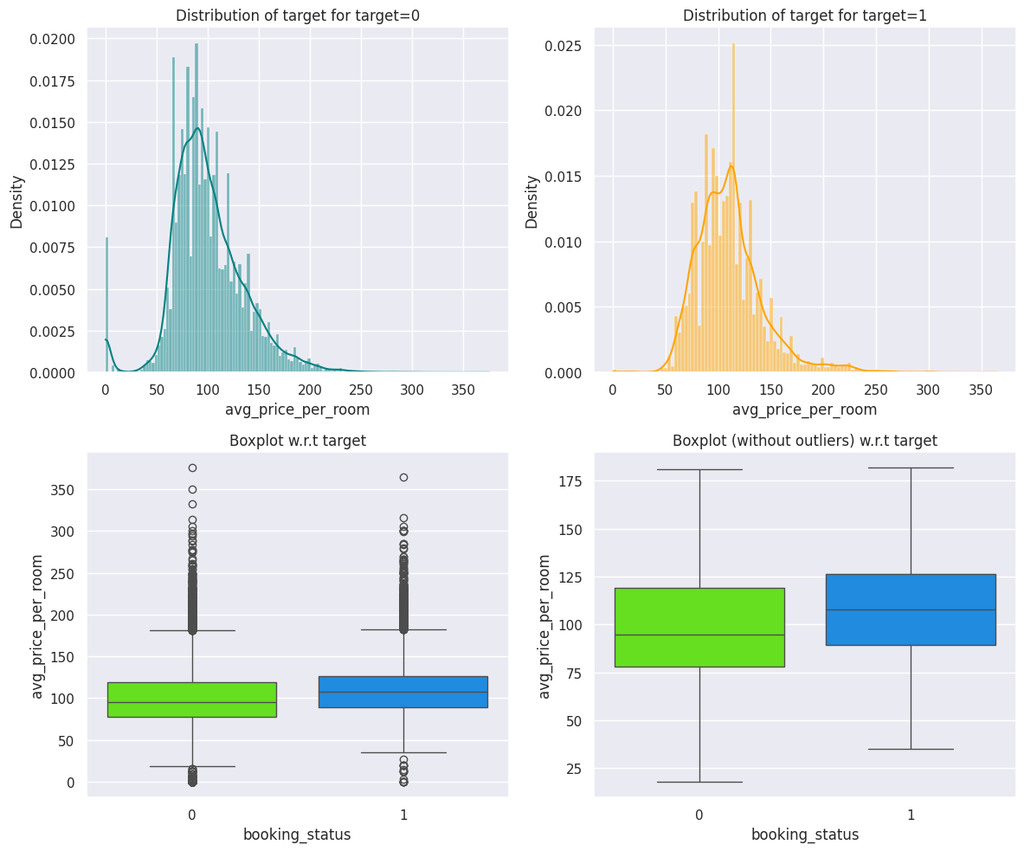

```python
distribution_plot_wrt_target(df, "avg_price_per_room", "booking_status")
```

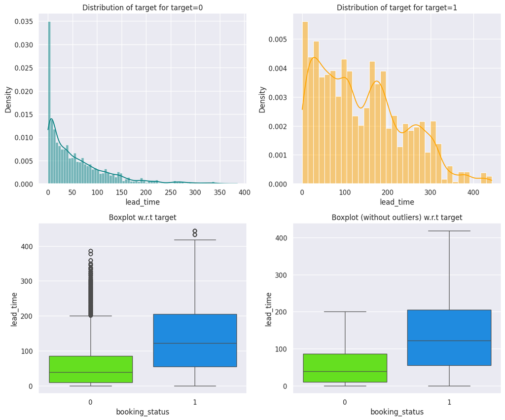

```python
distribution_plot_wrt_target(df, "lead_time", "booking_status") ## Complete the code to find distribution of lead time wrt booking status
```

Generally people travel with their spouse and children for vacations or other activities. Let's create a new dataframe of the customers who traveled with their families and analyze the impact on booking status.

```python
family_data = df[(df["no_of_children"] >= 0) & (df["no_of_adults"] > 1)]
family_data.shape
```

```
(28441, 19)
```

```python
family_data["no_of_family_members"] = (
    family_data["no_of_adults"] + family_data["no_of_children"]
)
```

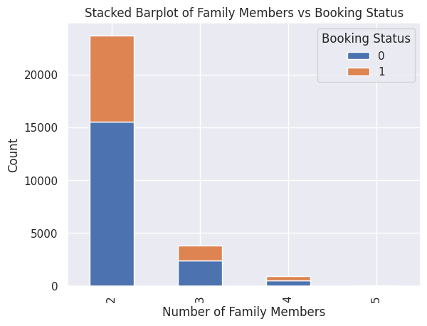

```python
import matplotlib.pyplot as plt
import seaborn as sns

data_to_plot = family_data.groupby(['no_of_family_members', 'booking_status']).size().unstack(fill_value=0)

data_to_plot.plot(kind='bar', stacked=True)

plt.xlabel('Number of Family Members')
plt.ylabel('Count')
plt.title('Stacked Barplot of Family Members vs Booking Status')
plt.legend(title='Booking Status')

plt.show()
```

**Let's do a similar analysis for the customer who stay for at least a day at the hotel.**

```python
stay_data = df[(df["no_of_week_nights"] > 0) & (df["no_of_weekend_nights"] > 0)]
stay_data.shape
```

```
(17094, 19)
```

```python
stay_data["total_days"] = (
    stay_data["no_of_week_nights"] + stay_data["no_of_weekend_nights"]
)
```

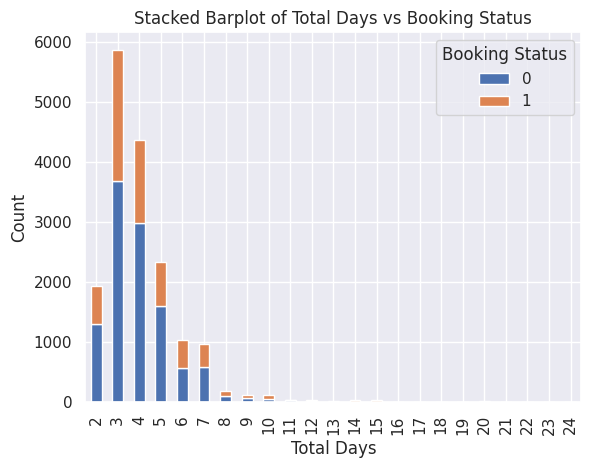

```python
import matplotlib.pyplot as plt
import seaborn as sns

data_to_plot = stay_data.groupby(['total_days', 'booking_status']).size().unstack(fill_value=0)

data_to_plot.plot(kind='bar', stacked=True)

plt.xlabel('Total Days')
plt.ylabel('Count')
plt.title('Stacked Barplot of Total Days vs Booking Status')
plt.legend(title='Booking Status')

plt.show()
```

Repeating guests are the guests who stay in the hotel often and are important to brand equity. Let's see what percentage of repeating guests cancel?

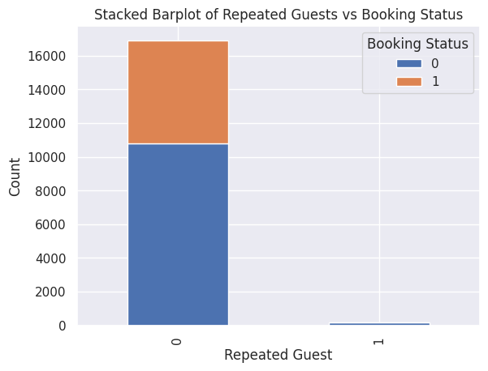

```python
import matplotlib.pyplot as plt
import seaborn as sns

data_to_plot = stay_data.groupby(['repeated_guest', 'booking_status']).size().unstack(fill_value=0)

data_to_plot.plot(kind='bar', stacked=True)

plt.xlabel('Repeated Guest')
plt.ylabel('Count')
plt.title('Stacked Barplot of Repeated Guests vs Booking Status')
plt.legend(title='Booking Status')

plt.show()
```

**Let's find out what are the busiest months in the hotel.**

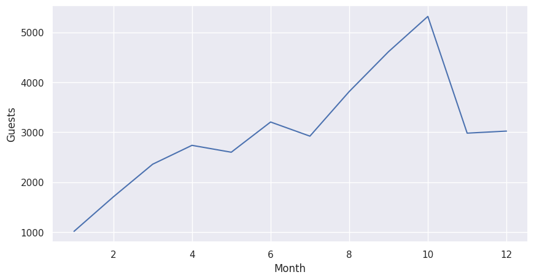

```python
monthly_data = df.groupby(["arrival_month"])["booking_status"].count()

monthly_data = pd.DataFrame(
    {"Month": list(monthly_data.index), "Guests": list(monthly_data.values)}
)

plt.figure(figsize=(10, 5))
sns.lineplot(data=monthly_data, x="Month", y="Guests")
plt.show()
```

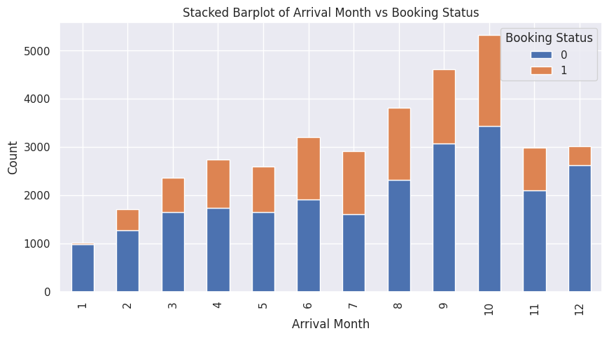

```python
import matplotlib.pyplot as plt
import seaborn as sns

data_to_plot = df.groupby(['arrival_month', 'booking_status']).size().unstack(fill_value=0)

data_to_plot.plot(kind='bar', stacked=True, figsize=(10, 5))

plt.xlabel('Arrival Month')
plt.ylabel('Count')
plt.title('Stacked Barplot of Arrival Month vs Booking Status')
plt.legend(title='Booking Status')

plt.show()
```

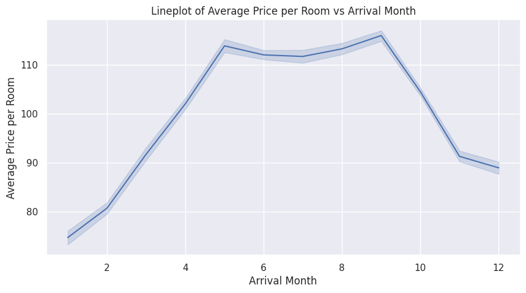

```python
import matplotlib.pyplot as plt
import seaborn as sns

plt.figure(figsize=(10, 5))
sns.lineplot(data=df, x='arrival_month', y='avg_price_per_room')

plt.xlabel('Arrival Month')
plt.ylabel('Average Price per Room')
plt.title('Lineplot of Average Price per Room vs Arrival Month')

plt.show()
```

### Outlier Check

- Let's check for outliers in the data.

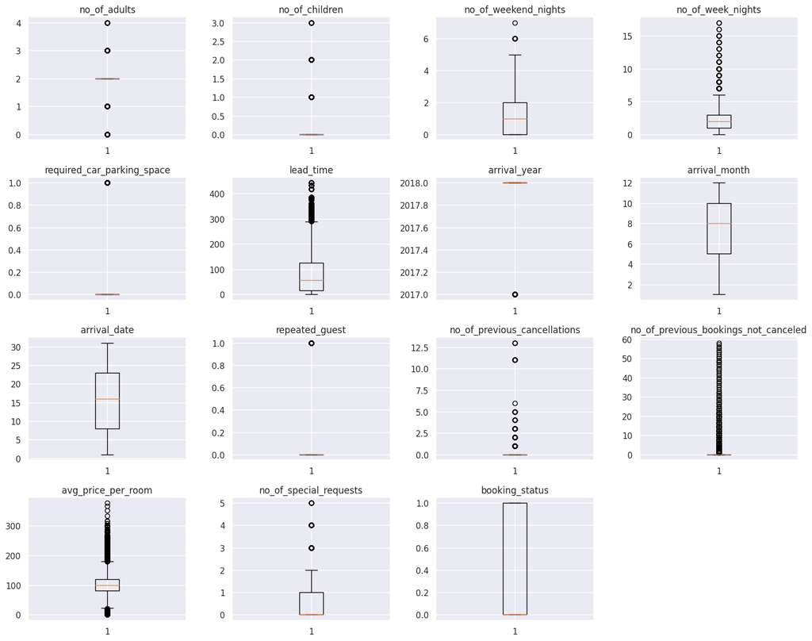

```python
numeric_columns = df.select_dtypes(include=np.number).columns.tolist()

plt.figure(figsize=(15, 12))

for i, variable in enumerate(numeric_columns):
    plt.subplot(4, 4, i + 1)
    plt.boxplot(df[variable], whis=1.5)
    plt.tight_layout()
    plt.title(variable)

plt.show()
```

## Model Building

### Logistic Regression (with statsmodels library)

#### Data Preparation for modeling (Logistic Regression)

```python
import statsmodels.api as sm
import pandas as pd
from sklearn.model_selection import train_test_split

X = df.drop(["booking_status"], axis=1)
Y = df["booking_status"]

X = sm.add_constant(X)

X = pd.get_dummies(X)

X_train, X_test, y_train, y_test = train_test_split(X, Y, test_size=0.3, random_state=1)
```

```python
print("Shape of Training set : ", X_train.shape)
print("Shape of test set : ", X_test.shape)
print("Percentage of classes in training set:")
print(y_train.value_counts(normalize=True))
print("Percentage of classes in test set:")
print(y_test.value_counts(normalize=True))
```

```
Shape of Training set :  (25392, 36306)
Shape of test set :  (10883, 36306)
Percentage of classes in training set:
0    0.670644
1    0.329356
Name: booking_status, dtype: float64
Percentage of classes in test set:
0    0.676376
1    0.323624
Name: booking_status, dtype: float64
```

#### Building Logistic Regression Model

```python
X = df.drop(["booking_status"], axis=1)
Y = df["booking_status"]
```

```python
from sklearn.model_selection import train_test_split

X_train, X_test, y_train, y_test = train_test_split(X, Y, test_size=0.3, random_state=1)
```

```python
X = df.drop(["booking_status", "Booking_ID"], axis=1)
```

```python
X = pd.get_dummies(X, drop_first=True)
```

```python
import pandas as pd
from sklearn.model_selection import train_test_split
import statsmodels.api as sm

X = df.drop(["booking_status", "Booking_ID"], axis=1)
X = pd.get_dummies(X, drop_first=True)
```

```python
X_train, X_test, y_train, y_test = train_test_split(X, df["booking_status"], test_size=0.3, random_state=1)
```

```python
X_train = X_train.to_numpy()
```

```python
y_train = np.asarray(y_train)
X_train = np.asarray(X_train)
```

```python
from sklearn.preprocessing import LabelEncoder

label_encoder = LabelEncoder()

Y = label_encoder.fit_transform(df['booking_status'])

X_train, X_test, y_train, y_test = train_test_split(X, Y, test_size=0.3, random_state=1)

logit = sm.Logit(y_train, X_train)

lg = logit.fit()

print(lg.summary())
```

```
Warning: Maximum number of iterations has been exceeded.
         Current function value: 0.426215
         Iterations: 35
                           Logit Regression Results
==============================================================================
Dep. Variable:                      y   No. Observations:                25392
Model:                          Logit   Df Residuals:                    25365
Method:                           MLE   Df Model:                           26
Date:                Sat, 27 Jan 2024   Pseudo R-squ.:                  0.3274
Time:                        04:37:18   Log-Likelihood:                -10822.
converged:                      False   LL-Null:                       -16091.
Covariance Type:            nonrobust   LLR p-value:                     0.000
========================================================================================================
                                           coef    std err          z      P>|z|      [0.025      0.975]
--------------------------------------------------------------------------------------------------------
no_of_adults                            -0.1009      0.038     -2.685      0.007      -0.175      -0.027
no_of_children                          -0.1629      0.057     -2.867      0.004      -0.274      -0.052
no_of_weekend_nights                    -0.1082      0.020     -5.478      0.000      -0.147      -0.069
no_of_week_nights                       -0.0405      0.012     -3.296      0.001      -0.065      -0.016
required_car_parking_space               1.6213      0.138     11.781      0.000       1.352       1.891
lead_time                               -0.0163      0.000    -63.030      0.000      -0.017      -0.016
arrival_year                             0.0012      0.000      9.205      0.000       0.001       0.001
arrival_month                            0.0615      0.006     10.261      0.000       0.050       0.073
arrival_date                            -0.0005      0.002     -0.234      0.815      -0.004       0.003
repeated_guest                           2.3698      0.609      3.892      0.000       1.176       3.563
no_of_previous_cancellations            -0.2667      0.086     -3.107      0.002      -0.435      -0.098
no_of_previous_bookings_not_canceled     0.1626      0.147      1.109      0.267      -0.125       0.450
avg_price_per_room                      -0.0201      0.001    -28.012      0.000      -0.022      -0.019
no_of_special_requests                   1.4550      0.030     48.644      0.000       1.396       1.514
type_of_meal_plan_Meal Plan 2           -0.0464      0.064     -0.724      0.469      -0.172       0.079
type_of_meal_plan_Meal Plan 3          -19.2937   1.23e+04     -0.002      0.999   -2.42e+04    2.42e+04
type_of_meal_plan_Not Selected          -0.3442      0.052     -6.571      0.000      -0.447      -0.242
room_type_reserved_Room_Type 2           0.3753      0.130      2.883      0.004       0.120       0.630
room_type_reserved_Room_Type 3          -0.0511      1.298     -0.039      0.969      -2.596       2.494
room_type_reserved_Room_Type 4           0.2599      0.053      4.903      0.000       0.156       0.364
room_type_reserved_Room_Type 5           0.6820      0.210      3.253      0.001       0.271       1.093
room_type_reserved_Room_Type 6           1.0239      0.146      7.010      0.000       0.738       1.310
room_type_reserved_Room_Type 7           1.4602      0.294      4.969      0.000       0.884       2.036
market_segment_type_Complementary       25.4264   1.23e+04      0.002      0.998   -2.42e+04    2.42e+04
market_segment_type_Corporate            1.3119      0.266      4.927      0.000       0.790       1.834
market_segment_type_Offline              2.3307      0.255      9.149      0.000       1.831       2.830
market_segment_type_Online               0.4995      0.252      1.985      0.047       0.006       0.993
========================================================================================================
```

```python
logit = sm.Logit(y_train, X_train)
```

```python
print("Training performance:")
```

```
Training performance:
```

```python
from sklearn.metrics import accuracy_score, precision_score, recall_score, f1_score

def model_performance_classification_statsmodels(model, X, y_true):

    y_pred_prob = model.predict(X)

    y_pred = [1 if prob > 0.5 else 0 for prob in y_pred_prob]

    accuracy = accuracy_score(y_true, y_pred)
    precision = precision_score(y_true, y_pred)
    recall = recall_score(y_true, y_pred)
    f1 = f1_score(y_true, y_pred)

    print(f"Accuracy: {accuracy:.4f}")
    print(f"Precision: {precision:.4f}")
    print(f"Recall: {recall:.4f}")
    print(f"F1 Score: {f1:.4f}")

print("Training performance:")
model_performance_classification_statsmodels(lg, X_train, y_train)
```

```
Training performance:
Accuracy: 0.8036
Precision: 0.8291
Recall: 0.8907
F1 Score: 0.8588
```

```python
!pip install statsmodels
```

#### Multicollinearity

```python
def checking_vif(predictors):
    vif = pd.DataFrame()
    vif["feature"] = predictors.columns

    vif["VIF"] = [
        variance_inflation_factor(predictors.values, i)
        for i in range(len(predictors.columns))
    ]
    return vif
```

```python
checking_vif(X_train)
```

|  | feature | VIF |
| --- | --- | --- |
| 0 | no_of_adults | 18.327604 |
| 1 | no_of_children | 2.110591 |
| 2 | no_of_weekend_nights | 2.003719 |
| 3 | no_of_week_nights | 3.776277 |
| 4 | required_car_parking_space | 1.073702 |
| 5 | lead_time | 2.474124 |
| 6 | arrival_year | 329.439218 |
| 7 | arrival_month | 7.206294 |
| 8 | arrival_date | 4.219627 |
| 9 | repeated_guest | 1.827912 |
| 10 | no_of_previous_cancellations | 1.400396 |
| 11 | no_of_previous_bookings_not_canceled | 1.659869 |
| 12 | avg_price_per_room | 18.598052 |
| 13 | no_of_special_requests | 2.016933 |
| 14 | type_of_meal_plan_Meal Plan 2 | 1.325659 |
| 15 | type_of_meal_plan_Meal Plan 3 | 1.025416 |
| 16 | type_of_meal_plan_Not Selected | 1.437891 |
| 17 | room_type_reserved_Room_Type 2 | 1.122473 |
| 18 | room_type_reserved_Room_Type 3 | 1.003472 |
| 19 | room_type_reserved_Room_Type 4 | 1.630708 |
| 20 | room_type_reserved_Room_Type 5 | 1.034848 |
| 21 | room_type_reserved_Room_Type 6 | 2.018977 |
| 22 | room_type_reserved_Room_Type 7 | 1.120129 |
| 23 | market_segment_type_Complementary | 4.548425 |
| 24 | market_segment_type_Corporate | 17.887527 |
| 25 | market_segment_type_Offline | 89.908876 |
| 26 | market_segment_type_Online | 198.241101 |

#### Dropping high p-value variables

- We will drop the predictor variables having a p-value greater than 0.05 as they do not significantly impact the target variable.
- But sometimes p-values change after dropping a variable. So, we'll not drop all variables at once.
- Instead, we will do the following:
  - Build a model, check the p-values of the variables, and drop the column with the highest p-value.
  - Create a new model without the dropped feature, check the p-values of the variables, and drop the column with the highest p-value.
  - Repeat the above two steps till there are no columns with p-value > 0.05.

The above process can also be done manually by picking one variable at a time that has a high p-value, dropping it, and building a model again. But that might be a little tedious and using a loop will be more efficient.

```python
cols = X_train.columns.tolist()

max_p_value = 1

while len(cols) > 0:

    x_train_aux = X_train[cols]

    model = sm.Logit(y_train, x_train_aux).fit(disp=False)

    p_values = model.pvalues
    max_p_value = max(p_values)

    feature_with_p_max = p_values.idxmax()

    if max_p_value > 0.05:
        cols.remove(feature_with_p_max)
    else:
        break

selected_features = cols
print(selected_features)
```

[output not shown]

```python
X_train1 = X_train[selected_features]
X_test1 = X_test[selected_features]
```

```python
import statsmodels.api as sm

logit1 = sm.Logit(y_train, X_train1)


lg1 = logit1.fit()

print(lg1.summary())
```

```
Optimization terminated successfully.
         Current function value: 0.426851
         Iterations 9
                           Logit Regression Results
==============================================================================
Dep. Variable:                      y   No. Observations:                25392
Model:                          Logit   Df Residuals:                    25372
Method:                           MLE   Df Model:                           19
Date:                Sat, 27 Jan 2024   Pseudo R-squ.:                  0.3264
Time:                        04:42:07   Log-Likelihood:                -10839.
converged:                       True   LL-Null:                       -16091.
Covariance Type:            nonrobust   LLR p-value:                     0.000
==================================================================================================
                                     coef    std err          z      P>|z|      [0.025      0.975]
--------------------------------------------------------------------------------------------------
no_of_adults                      -0.0953      0.037     -2.560      0.010      -0.168      -0.022
no_of_children                    -0.1581      0.057     -2.783      0.005      -0.269      -0.047
no_of_weekend_nights              -0.1103      0.020     -5.593      0.000      -0.149      -0.072
no_of_week_nights                 -0.0423      0.012     -3.451      0.001      -0.066      -0.018
required_car_parking_space         1.6213      0.138     11.777      0.000       1.351       1.891
lead_time                         -0.0163      0.000    -63.689      0.000      -0.017      -0.016
arrival_year                       0.0015   5.32e-05     27.583      0.000       0.001       0.002
arrival_month                      0.0622      0.006     10.408      0.000       0.050       0.074
repeated_guest                     2.7033      0.559      4.833      0.000       1.607       3.800
no_of_previous_cancellations      -0.2270      0.077     -2.957      0.003      -0.377      -0.077
avg_price_per_room                -0.0206      0.001    -29.715      0.000      -0.022      -0.019
no_of_special_requests             1.4561      0.030     48.761      0.000       1.398       1.515
type_of_meal_plan_Not Selected    -0.3492      0.052     -6.683      0.000      -0.452      -0.247
room_type_reserved_Room_Type 2     0.3720      0.130      2.860      0.004       0.117       0.627
room_type_reserved_Room_Type 4     0.2617      0.053      4.972      0.000       0.159       0.365
room_type_reserved_Room_Type 5     0.7027      0.209      3.367      0.001       0.294       1.112
room_type_reserved_Room_Type 6     1.0456      0.146      7.180      0.000       0.760       1.331
room_type_reserved_Room_Type 7     1.5014      0.293      5.124      0.000       0.927       2.076
market_segment_type_Corporate      0.8122      0.103      7.907      0.000       0.611       1.014
market_segment_type_Offline        1.8146      0.050     36.184      0.000       1.716       1.913
==================================================================================================
```

```python
print("Training performance:")
model_performance_classification_statsmodels(lg1, X_train1, y_train)
```

```
Training performance:
Accuracy: 0.8040
Precision: 0.8292
Recall: 0.8914
F1 Score: 0.8592
```

```python
odds = np.exp(lg1.params)

perc_change_odds = (np.exp(lg1.params) - 1) * 100

pd.set_option("display.max_columns", None)

pd.DataFrame({"Odds": odds, "Change_odd%": perc_change_odds}, index=X_train1.columns).T
```

|  | no_of_adults | no_of_children | no_of_weekend_nights | no_of_week_nights | required_car_parking_space | lead_time | arrival_year | arrival_month | repeated_guest | no_of_previous_cancellations | avg_price_per_room | no_of_special_requests | type_of_meal_plan_Not Selected | room_type_reserved_Room_Type 2 | room_type_reserved_Room_Type 4 | room_type_reserved_Room_Type 5 | room_type_reserved_Room_Type 6 | room_type_reserved_Room_Type 7 | market_segment_type_Corporate | market_segment_type_Offline |
| --- | --- | --- | --- | --- | --- | --- | --- | --- | --- | --- | --- | --- | --- | --- | --- | --- | --- | --- | --- | --- |
| Odds | 0.909100 | 0.853751 | 0.895590 | 0.958613 | 5.059663 | 0.983852 | 1.001467 | 1.064167 | 14.929391 | 0.796940 | 0.979640 | 4.289334 | 0.705252 | 1.450570 | 1.299174 | 2.019225 | 2.845241 | 4.487895 | 2.252814 | 6.138531 |
| Change_odd% | -9.090028 | -14.624885 | -10.441039 | -4.138694 | 405.966301 | -1.614813 | 0.146748 | 6.416706 | 1392.939120 | -20.305959 | -2.035962 | 328.933378 | -29.474780 | 45.057028 | 29.917445 | 101.922480 | 184.524110 | 348.789535 | 125.281403 | 513.853100 |

```python
!pip install statsmodels
import statsmodels.api as sm
```

```python
def confusion_matrix_statsmodels(model, X, y):

    y_pred_prob = model.predict(X).values

    y_pred = (y_pred_prob >= 0.5).astype(int)

    confusion_matrix = pd.crosstab(y, y_pred, rownames=['Actual'], colnames=['Predicted'])

    accuracy = (confusion_matrix.iloc[0, 0] + confusion_matrix.iloc[1, 1]) / len(y)

    precision = confusion_matrix.iloc[1, 1] / (confusion_matrix.iloc[1, 1] + confusion_matrix.iloc[0, 1])

    recall = confusion_matrix.iloc[1, 1] / (confusion_matrix.iloc[1, 1] + confusion_matrix.iloc[1, 0])

    f1_score = 2 * (precision * recall) / (precision + recall)

    print("Confusion Matrix:")
    print(confusion_matrix)
    print("\nAccuracy:", accuracy)
    print("Precision:", precision)
    print("Recall:", recall)
    print("F1 Score:", f1_score)
```

```python
confusion_matrix_statsmodels(lg1, X_train1, y_train)
```

```
Confusion Matrix:
Predicted     0      1
Actual
0          5237   3126
1          1850  15179

Accuracy: 0.8040327662255828
Precision: 0.8292269871619776
Recall: 0.8913617945857067
F1 Score: 0.8591724684439916
```

```python
print("Training performance:")

log_reg_model_train_perf
```

[output not shown]

```python
from sklearn.metrics import roc_auc_score, roc_curve
```